# Supervised_Learning Project - by Chirag Lodaya

## Objective: To predict the likelihood of a liability customer buying personal loans.

### Data Description: The file Bank.xls contains data on 5000 customers. The data include customer demographic information (age, income, etc.), the customer's relationship with the bank (mortgage, securities account, etc.), and the customer response to the last personal loan campaign (Personal Loan). Among these 5000 customers, only 480 (= 9.6%) accepted the personal loan that was offered to them in the earlier campaign.

### Domain: Banking

### Context: This case is about a bank (Thera Bank) whose management wants to explore ways of converting its liability customers to personal loan customers (while retaining them as depositors). A campaign that the bank ran last year for liability customers showed a healthy conversion rate of over 9% success. This has encouraged the retail marketing department to devise campaigns with better target marketing to increase the success ratio with minimal budget.

### Attribute Information:

### ID : Customer ID

### Age : Customer's age in completed years

### Experience : #years of professional experience

### Income : Annual income of the customer in *dollar 000

### ZIP Code : Home Address ZIP code.

### Family : Family size of the customer

### CCAvg : Avg. spending on credit cards per month in *dollar 000

### Education : Education Level. - Undergrad, Graduate or Advanced/Professional

### Mortgage : Value of house mortgage if any. in *dollar 000

### Personal Loan : Did this customer accept the personal loan offered in the last campaign?

### Securities Account : Does the customer have a securities account with the bank?

### CD Account : Does the customer have a certificate of deposit (CD) account with the bank?

### Online : Does the customer use internet banking facilities?

### Credit card : Does the customer use a credit card issued by UniversalBank?

```python
import numpy as np
import pandas as pd
import numpy as np
import matplotlib.pyplot as plt
import seaborn as sns
%matplotlib inline
from scipy.stats import zscore
from sklearn import tree
from sklearn.tree import DecisionTreeClassifier
from sklearn.ensemble import BaggingClassifier
from sklearn.feature_extraction.text import CountVectorizer
from sklearn.naive_bayes import GaussianNB
from sklearn.ensemble import RandomForestClassifier
from sklearn.ensemble import BaggingClassifier, RandomForestClassifier
from sklearn.neighbors import KNeighborsClassifier
from sklearn import model_selection
from sklearn.model_selection import train_test_split
from sklearn import metrics
from sklearn.linear_model import LogisticRegression
from sklearn.naive_bayes import GaussianNB
```

```python
data = pd.read_csv("Bank_Personal_Loan_Modelling.csv")
print("Columns of the dataset: \n\n", data.columns)
print("\n\nFirst five tuples/rowds of the dataset: \n\n",data.head())
print("\n\n Dimensions of data: \n\n", data.shape)
print("\n\n Datcount and Datatype of the dataset: \n")
print(data.info())
```

```
Columns of the dataset:

 Index(['ID', 'Age', 'Experience', 'Income', 'ZIP Code', 'Family', 'CCAvg',
       'Education', 'Mortgage', 'Personal Loan', 'Securities Account',
       'CD Account', 'Online', 'CreditCard'],
      dtype='object')


First five tuples/rowds of the dataset:

    ID  Age  Experience  Income  ZIP Code  Family  CCAvg  Education  Mortgage  \
0   1   25           1      49     91107       4    1.6          1         0
1   2   45          19      34     90089       3    1.5          1         0
2   3   39          15      11     94720       1    1.0          1         0
3   4   35           9     100     94112       1    2.7          2         0
4   5   35           8      45     91330       4    1.0          2         0

   Personal Loan  Securities Account  CD Account  Online  CreditCard
0              0                   1           0       0           0
1              0                   1           0       0           0
2              0                   0           0       0           0
3              0                   0           0       0           0
4              0                   0           0       0           1


 Dimensions of data:

 (5000, 14)


 Datcount and Datatype of the dataset:

<class 'pandas.core.frame.DataFrame'>
RangeIndex: 5000 entries, 0 to 4999
Data columns (total 14 columns):
 #   Column              Non-Null Count  Dtype
---  ------              --------------  -----
 0   ID                  5000 non-null   int64
 1   Age                 5000 non-null   int64
 2   Experience          5000 non-null   int64
 3   Income              5000 non-null   int64
 4   ZIP Code            5000 non-null   int64
 5   Family              5000 non-null   int64
 6   CCAvg               5000 non-null   float64
 7   Education           5000 non-null   int64
 8   Mortgage            5000 non-null   int64
 9   Personal Loan       5000 non-null   int64
 10  Securities Account  5000 non-null   int64
 11  CD Account          5000 non-null   int64
 12  Online              5000 non-null   int64
 13  CreditCard          5000 non-null   int64
dtypes: float64(1), int64(13)
memory usage: 547.0 KB
None
```

## In the above block of code:

### - We try to analyze the data set details

### - The columns of the data set are:

### - ID: This is not a really significant attriubute as it just looks like a serial number for identification(Nominal)

### - Age: Age of the customer in years

### - Experience: Years of experince of work of the customer

### - Income: Annual income in dollars(*1000)

### - ZIP code: The zipcode of the are the cutsomer is living in (This is Nominal)

### - Family - The family size of the cutsomer (Ordinal)

### - CCAVG- Average credit card amount used by the customer

### - Education - This is Ordinal with levels 1,2,3

### - Mortgage - The value of House mortgage of the customer

### - Securities Account: Whether customer has Security account in the bank(Binary)

### - CD Account: Whether customer has Certificate of Deposit in the bank(Binary)

### - Online: Whether customer has Online account in the bank(Binary)

### - CreditCard: Whether customer uses credit card of the bank(Binary)

### - Whether customer took the loan offered by the bank in previous campign (This is target variable)

# Checking the missing values and 5 point summary and removing negative values

```python
print(pd.DataFrame(data.isnull().sum(), columns= ['Number of missing values']))
print("\n\n Five point summary:\n")
print(data.describe())
print("\n\n Unique values:\n")
print(data.apply(lambda x: len(x.unique())))
print("\n\nNegative data in experience data field:",data[data['Experience'] < 0]['Experience'].count())
dfExp = data.loc[data['Experience'] >0]
negExp = data.Experience < 0
column_name = 'Experience'
mylist = data.loc[negExp]['ID'].tolist()
for id in mylist:
    age = data.loc[np.where(data['ID']==id)]["Age"].tolist()[0]
    education = data.loc[np.where(data['ID']==id)]["Education"].tolist()[0]
    df_filtered = dfExp[(dfExp.Age == age) & (dfExp.Education == education)]
    exp = df_filtered['Experience'].median()
    data.loc[data.loc[np.where(data['ID']==id)].index, 'Experience'] = exp
print("Negative data after changes:",data[data['Experience'] < 0]['Experience'].count())
```

```
                    Number of missing values
ID                                         0
Age                                        0
Experience                                 0
Income                                     0
ZIP Code                                   0
Family                                     0
CCAvg                                      0
Education                                  0
Mortgage                                   0
Personal Loan                              0
Securities Account                         0
CD Account                                 0
Online                                     0
CreditCard                                 0


 Five point summary:

                ID          Age   Experience       Income      ZIP Code  \
count  5000.000000  5000.000000  5000.000000  5000.000000   5000.000000
mean   2500.500000    45.338400    20.104600    73.774200  93152.503000
std    1443.520003    11.463166    11.467954    46.033729   2121.852197
min       1.000000    23.000000    -3.000000     8.000000   9307.000000
25%    1250.750000    35.000000    10.000000    39.000000  91911.000000
50%    2500.500000    45.000000    20.000000    64.000000  93437.000000
75%    3750.250000    55.000000    30.000000    98.000000  94608.000000
max    5000.000000    67.000000    43.000000   224.000000  96651.000000

            Family        CCAvg    Education     Mortgage  Personal Loan  \
count  5000.000000  5000.000000  5000.000000  5000.000000    5000.000000
mean      2.396400     1.937938     1.881000    56.498800       0.096000
std       1.147663     1.747659     0.839869   101.713802       0.294621
min       1.000000     0.000000     1.000000     0.000000       0.000000
25%       1.000000     0.700000     1.000000     0.000000       0.000000
50%       2.000000     1.500000     2.000000     0.000000       0.000000
75%       3.000000     2.500000     3.000000   101.000000       0.000000
max       4.000000    10.000000     3.000000   635.000000       1.000000

       Securities Account  CD Account       Online   CreditCard
```

[output cut: 16 more lines]

```
ZIP Code               467
Family                   4
CCAvg                  108
Education                3
Mortgage               347
Personal Loan            2
Securities Account       2
CD Account               2
Online                   2
CreditCard               2
dtype: int64


Negative data in experience data field: 52
Negative data after changes: 0
```

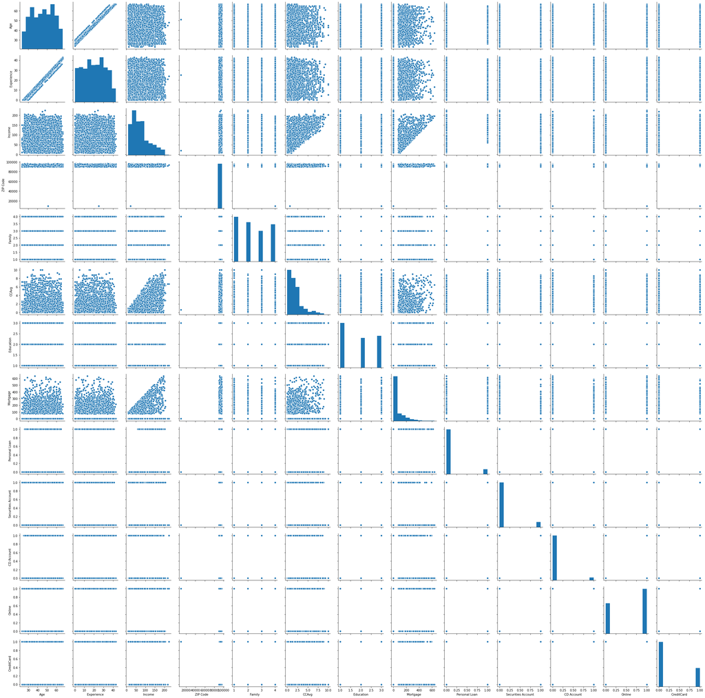

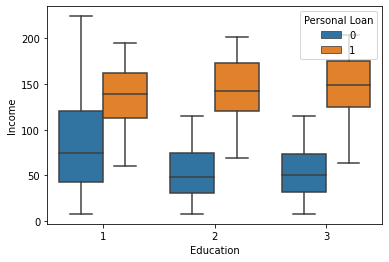

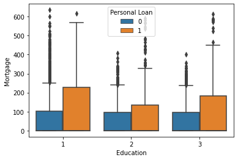

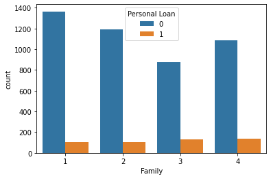

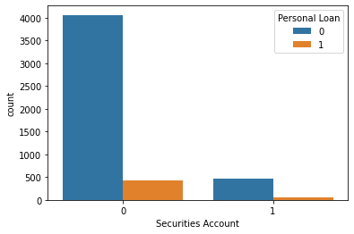

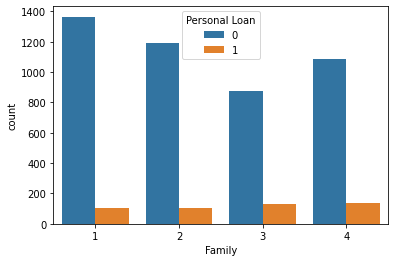

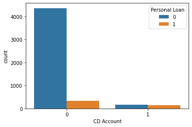

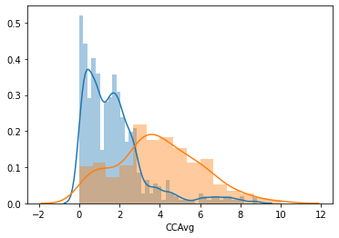

```
Credit card spending of Non-Loan customers: 1400.0
Credit card spending of Loan customers: 3800.0
```

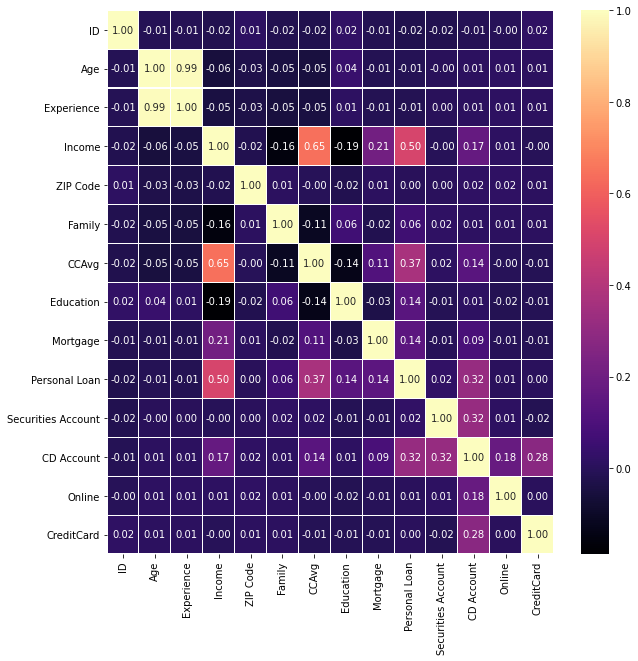

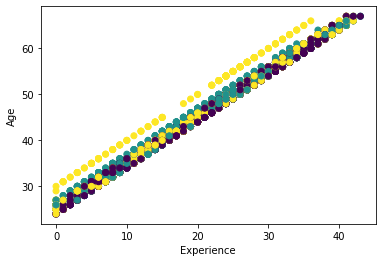

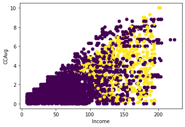

```python
sns.pairplot(data.iloc[:,1:])
plt.show()
sns.boxplot(x='Education',y='Income',hue='Personal Loan',data=data)
plt.show()
sns.boxplot(x="Education", y='Mortgage', hue="Personal Loan", data=data)
plt.show()
sns.countplot(x='Family',hue='Personal Loan',data=data)
plt.show()
sns.countplot(x="Securities Account", data=data,hue="Personal Loan")
plt.show()
sns.countplot(x='Family',data=data,hue='Personal Loan')
plt.show()
sns.countplot(x='CD Account',data=data,hue='Personal Loan')
plt.show()
x=data[data['Personal Loan'] == 0]['CCAvg']
y=data[data['Personal Loan'] == 1]['CCAvg']
sns.distplot(x)
sns.distplot(y)
plt.show()
print('Credit card spending of Non-Loan customers:',x.median()*1000)
print('Credit card spending of Loan customers:', y.median()*1000)
fig,ax = plt.subplots(figsize=(10, 10))
sns.heatmap(data.corr(), ax=ax, annot=True, linewidths=0.05, fmt= '.2f',cmap="magma")
plt.show()
fig, ax = plt.subplots()
ax.scatter(data['Experience'],data['Age'],c=data['Education'])
plt.xlabel('Experience')
plt.ylabel('Age')
fig, ax = plt.subplots()
ax.scatter(data['Income'],data['CCAvg'] ,c=data['Personal Loan'])
plt.xlabel('Income')
plt.ylabel('CCAvg')
```

## - Influnce of CCavg on personal loan

### Blue is not taken loan and orange is taken loan, we can say from the graph that, people who have taken loans have a higer credit card usage average as compared to the people who have not taken loans.

## - Next we see the heat map (Correlation):

### - Age and experience are highly correlated (positve) as its common knowledge that as age increase, work experience increases

### - CCAVG and Income is moderately correlated(Positive), as this is common knowledge, with increse in income, credit card limits increase and spending becomes more

### - In the graph we can see the positive correlation of experince and age in relation to education, there is a gap for close to 40's and lower educated people as well

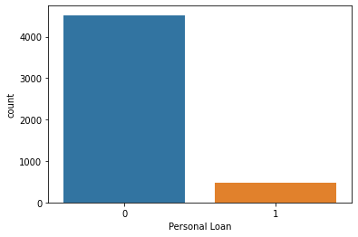

```
People who have taken loan: 480

People who have not taken loan: 4520

Percetage of bank customers who have taken loan: 9.6 %
```

```python
sns.countplot(data['Personal Loan'])
plt.show()
c1= data[data['Personal Loan']==1]
c2= data[data['Personal Loan']==0]
c1=c1.count()
c2=c2.count()
d1=c1['ID']
d2=c2['ID']
print("\nPeople who have taken loan:", d1)
print("\nPeople who have not taken loan:", d2)
print("\nPercetage of bank customers who have taken loan:", ((d1/5000)*100), "%")
```

## In the above block of code we see the target attribute Personal loan, out of al the customer in previous phase 480 of them took loan out of 5000, i.e almost 9.6 %. The distribution of the target attribute with respect to the previous attributes, is done in the previous section

```python
training_set, testing_set = train_test_split(data.drop(['ID','Experience'], axis=1), test_size=0.3 , random_state=100)
y_train = training_set['Personal Loan']
y_test = testing_set['Personal Loan']
x_train=training_set.drop(['Personal Loan'], axis=1)
x_test=testing_set.drop(['Personal Loan'], axis=1)
print("{0:0.2f}% data is in training set".format((len(x_train)/len(data.index)) * 100))
print("{0:0.2f}% data is in test set".format((len(x_test)/len(data.index)) * 100))
```

```
70.00% data is in training set
30.00% data is in test set
```

## In the above block of code we split the data into training and testing set. i.e in the ration of 70%(Train) and 30%(Test)

```python
model = LogisticRegression(solver="liblinear")
model.fit(x_train, y_train)
#predict on test
y_predict = model.predict(x_test)
coef_df = pd.DataFrame(model.coef_)
coef_df['intercept'] = model.intercept_
print("Co effeciencts of the Logistic regression model\n\n", coef_df)
model_score = model.score(x_test, y_test)
print("\n\nAccuracy of Logistic regression model", model_score*100, "%")

loan_model = GaussianNB()
loan_model.fit(x_train, y_train.ravel())
loan_train_predict = loan_model.predict(x_train)
loan_test_predict = loan_model.predict(x_test)
print("\n\nAccuracy of Naive Bayes Model: {0:.4f}".format(metrics.accuracy_score(y_test, loan_test_predict)*100), "%")


NNH = KNeighborsClassifier(n_neighbors= 5 , weights = 'distance' )
NNH.fit(x_train, y_train)
predicted_labels = NNH.predict(x_test)
print("\n\nAccuracy of KNN model:", NNH.score(x_test, y_test)*100, "%")
```

```
Co effeciencts of the Logistic regression model

           0         1         2         3         4         5         6  \
0  0.000433  0.034362 -0.000063  0.000347  0.001023  0.000518  0.000399

          7         8         9        10  intercept
0  0.000032  0.000188 -0.000027  0.000003  -0.000002


Accuracy of Logistic regression model 89.93333333333334 %


Accuracy of Naive Bayes Model: 88.6667 %


Accuracy of KNN model: 89.0 %
```

## In the above block of code we use our segregated data sets, that is training data to train model and testing data to test model.

## - First we use Logistic regression and when implemented it comes upto an accuracy of 89.9%(on test data)

## - Next we use Naive Bayes, here we end up with an accuracy of 88.66%(on test data)

## - Finally we usee KNN and the accuracy comes upto 89%(on test data)

```
Confusion Matrix for Logistic Regression Model:
```

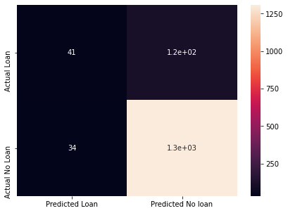

```
Confusion Matrix for Naive Bayes Model:
```

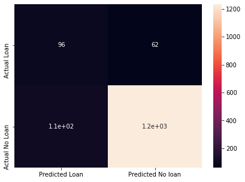

```
Confusion Matrix for kNN Model:
```

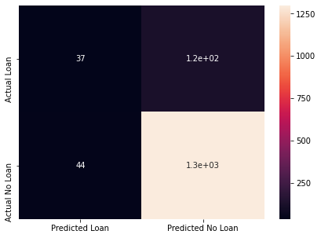

```python
cm=metrics.confusion_matrix(y_test, y_predict, labels=[1, 0])
df_cm = pd.DataFrame(cm, index = [i for i in ["Actual Loan","Actual No Loan"]],
                  columns = [i for i in ["Predicted Loan","Predicted No loan"]])
print("Confusion Matrix for Logistic Regression Model:\n")
plt.figure(figsize = (7,5))
sns.heatmap(df_cm, annot=True)
plt.show()

print("Confusion Matrix for Naive Bayes Model:\n")
cm=metrics.confusion_matrix(y_test, loan_test_predict, labels=[1, 0])
df_cm = pd.DataFrame(cm, index = [i for i in ["Actual Loan","Actual No Loan"]],
                  columns = [i for i in ["Predicted Loan","Predicted No loan"]])
plt.figure(figsize = (7,5))
sns.heatmap(df_cm, annot=True)
plt.show()

print("Confusion Matrix for kNN Model:\n")
cm=metrics.confusion_matrix(y_test, predicted_labels, labels=[1,0])
df_cm = pd.DataFrame(cm, index = [i for i in ["Actual Loan","Actual No Loan"]],
                  columns = [i for i in ["Predicted Loan","Predicted No Loan"]])
plt.figure(figsize = (7,5))
sns.heatmap(df_cm, annot=True)
plt.show()
```

## In the above block of code we can see Confusion matrix of all the three models we implemented

```
Logistic: 0.908000 (0.008149)
KNN: 0.898600 (0.008902)
Naive Bayes: 0.885600 (0.010385)
```

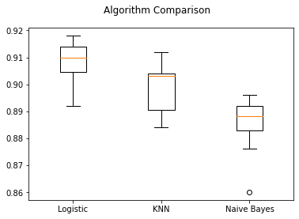

```python
x=data.drop(['ID','Experience'], axis=1)
y=x['Personal Loan']
x=x.drop(['Personal Loan'], axis=1)
models = []
LogisticRegression
models.append(('Logistic', LogisticRegression()))
models.append(('KNN', KNeighborsClassifier()))
models.append(('Naive Bayes', GaussianNB()))

results = []
names = []
scoring = 'accuracy'
for name, model in models:
	kfold = model_selection.KFold(n_splits=10, random_state=12345)
	cv_results = model_selection.cross_val_score(model, x, y, cv=kfold, scoring=scoring)
	results.append(cv_results)
	names.append(name)
	msg = "%s: %f (%f)" % (name, cv_results.mean(), cv_results.std())
	print(msg)
# boxplot algorithm comparison
fig = plt.figure()
fig.suptitle('Algorithm Comparison')
ax = fig.add_subplot(111)
plt.boxplot(results)
ax.set_xticklabels(names)
plt.show()
```

## also naive bayes could be a choice, if training examples were few, but then here we have decent amoun of tuples/rows, hence it is the best choice to go with the model of higest accuracy and also good speed

## Hence we choose Logistic regression as our final model for the appliacation.